# ISYE 6402 Homework 4

```r
summary(final_model)
```

```
##           Length Class  Mode
## coef        5    -none- numeric
## sigma2      1    -none- numeric
## var.coef   25    -none- numeric
## mask        5    -none- logical
## loglik      1    -none- numeric
## aic         1    -none- numeric
## arma        7    -none- numeric
## residuals 142    ts     numeric
## call        4    -none- call
## series      1    -none- character
## code        1    -none- numeric
## n.cond      1    -none- numeric
## nobs        1    -none- numeric
## model      10    -none- list
```

```r
#### Test for Uncorrelated Residuals for the final model
Box.test(final_model$resid, lag = (porder+qorder+1), type = "Box-Pierce", fitdf = (porder+qorder))
```

```
##
##  Box-Pierce test
##
## data:  final_model$resid
## X-squared = 0.55016, df = 1, p-value = 0.4583
```

```r
Box.test(final_model$resid, lag = (porder+qorder+1), type = "Ljung-Box", fitdf = (porder+qorder))
```

```
##
##  Box-Ljung test
##
## data:  final_model$resid
## X-squared = 0.56952, df = 1, p-value = 0.4505
```

```r
#### Test Uncorrelated Residuals for the smaller model
Box.test(modarma$resid, lag = (porder+qorder+1), type = "Box-Pierce", fitdf = (porder+qorder))
```

```
##
##  Box-Pierce test
##
## data:  modarma$resid
## X-squared = 0.050029, df = 1, p-value = 0.823
```

```r
Box.test(modarma$resid, lag = (porder+qorder+1), type = "Ljung-Box", fitdf = (porder+qorder))
```

```
##
##  Box-Ljung test
##
## data:  modarma$resid
## X-squared = 0.052277, df = 1, p-value = 0.8191
```

```r
final_model_cn_m = final_model




#now repeat for JPY....
par(mfrow=c(1,1))
TimeSeriesData = monthly.JPY.ts.train
orderMax = 8

mod = ar(TimeSeriesData,order.max=orderMax)

# What is the selected order?
print(mod$order)
```

```
## [1] 1
```

```r
# find the list of arguments provided by AR fit
summary(mod)
```

```
##              Length Class  Mode
## order          1    -none- numeric
## ar             1    -none- numeric
## var.pred       1    -none- numeric
## x.mean         1    -none- numeric
## aic            9    -none- numeric
## n.used         1    -none- numeric
## n.obs          1    -none- numeric
## order.max      1    -none- numeric
## partialacf     8    -none- numeric
## resid        142    -none- numeric
## method         1    -none- character
## series         1    -none- character
## frequency      1    -none- numeric
## call           3    -none- call
## asy.var.coef   1    -none- numeric
```

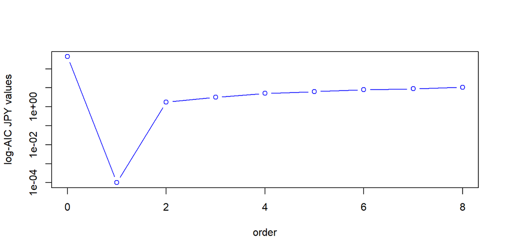

```r
# plot aic values
# On non-log scale it is difficult to detect the minimum.
plot(c(0:orderMax),mod$aic+.0001, type="b",log="y",xlab="order",ylab="log-AIC JPY values", col="blue")
```

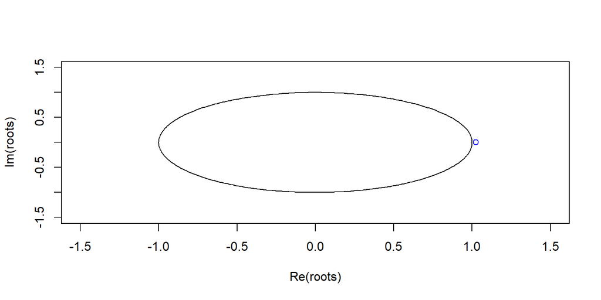

```r
# Are the roots of fitted AR within the unit circle?
# extract roots from the model output
roots = polyroot(c(1,(-mod$ar)))
# adjust the x and y -axis limits to include the full circle
plot(roots,xlim=c(-1.5,1.5),ylim=c(-1.5,1.5), col="blue")
# draw a unit root circle
lines(complex(arg = seq(0,2*pi,len=300)))
```

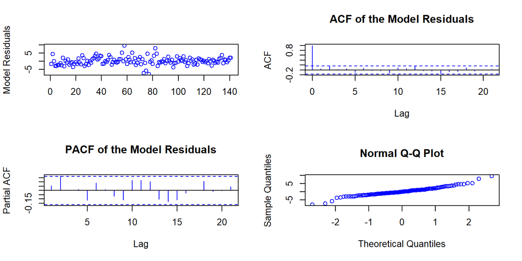

```r
# residuals analysis
resids = mod$resid[(mod$order+1): length(mod$resid)]

par(mfrow=c(2,2))
plot(resids,xlab="",ylab="Model Residuals", col="blue")
acf(resids,main='ACF of the Model Residuals', col="blue")
pacf(resids,main='PACF of the Model Residuals', col="blue")
qqnorm(resids, col="blue")
```

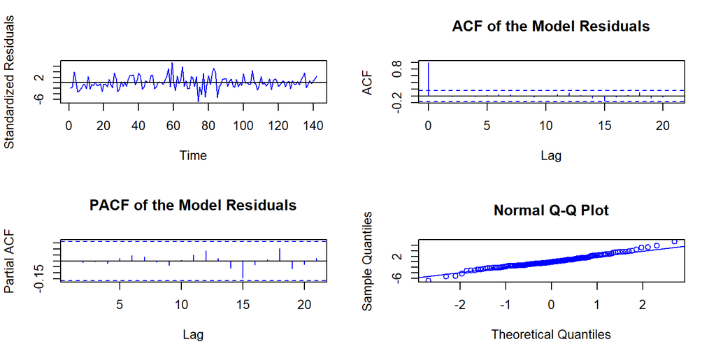

```r
###### Fit an ARMA(p,q) for some values of p and q #####
modarma = arima(TimeSeriesData, order = c(8,0,8),method = "ML")

par (mfrow=c(2,2))
plot(resid(modarma), ylab='Standardized Residuals', col="blue")
abline(h=0)
acf(as.vector(resid(modarma)),main= 'ACF of the Model Residuals', col="blue")
pacf(as.vector(resid(modarma)),main='PACF of the Model Residuals', col="blue")
qqnorm(resid(modarma), col="blue")
qqline(resid(modarma), col="blue")
```

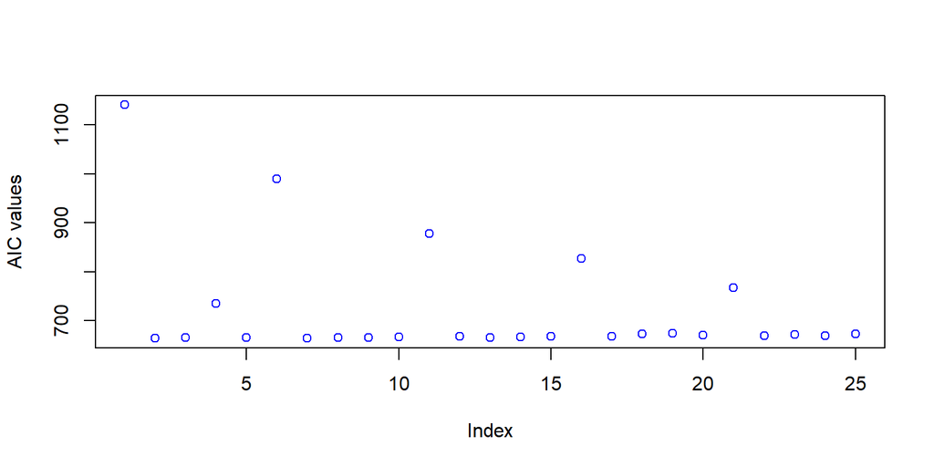

```r
## Order selection -- AIC
n = length(TimeSeriesData)
norder = 5
p = c(1:norder)-1; q = c(1:norder)-1
aic = matrix(0,norder,norder)
for(i in 1:norder){
   for(j in 1:norder){
    modij = arima(TimeSeriesData,order = c(p[i],0,q[j]), method='ML')
    aic[i,j] = modij$aic-2*(p[i]+q[j]+1)+2*(p[i]+q[j]+1)*n/(n-p[i]-q[j]-2)
   }
 }

par (mfrow=c(1,1))
#which order to select?
aicv = as.vector(aic)
plot(aicv,ylab="AIC values", col="blue")
```

```r
indexp = rep(c(1:norder),norder)
indexq = rep(c(1:norder),each=norder)
indexaic = which(aicv == min(aicv))
porder = indexp[indexaic]-1
qorder = indexq[indexaic]-1

porder
```

```
## [1] 1
```

```r
qorder
```

```
## [1] 1
```

```r
min(aicv) #664.0323
```

```
## [1] 664.0323
```

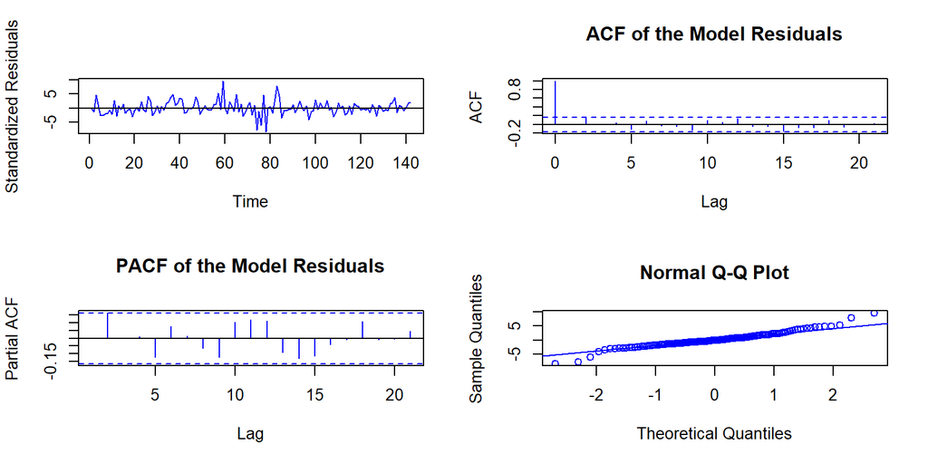

```r
#Create Final Model
final_model = arima(TimeSeriesData,order = c(porder,0,qorder), method='ML')

par (mfrow=c(2,2))
plot(resid(final_model), ylab='Standardized Residuals', col="blue")
abline(h=0)
acf(as.vector(resid(final_model)),main= 'ACF of the Model Residuals', col="blue")
pacf(as.vector(resid(final_model)),main='PACF of the Model Residuals', col="blue")
qqnorm(resid(final_model), col="blue")
qqline(resid(final_model), col="blue")
```

```r
summary(final_model)
```

```
##           Length Class  Mode
## coef        3    -none- numeric
## sigma2      1    -none- numeric
## var.coef    9    -none- numeric
## mask        3    -none- logical
## loglik      1    -none- numeric
## aic         1    -none- numeric
## arma        7    -none- numeric
## residuals 142    ts     numeric
## call        4    -none- call
## series      1    -none- character
## code        1    -none- numeric
## n.cond      1    -none- numeric
## nobs        1    -none- numeric
## model      10    -none- list
```

```r
#### Test for Uncorrelated Residuals for the final model
Box.test(final_model$resid, lag = (porder+qorder+1), type = "Box-Pierce", fitdf = (porder+qorder))
```

```
##
##  Box-Pierce test
##
## data:  final_model$resid
## X-squared = 3.7164, df = 1, p-value = 0.05388
```

```r
Box.test(final_model$resid, lag = (porder+qorder+1), type = "Ljung-Box", fitdf = (porder+qorder))
```

```
##
##  Box-Ljung test
##
## data:  final_model$resid
## X-squared = 3.8225, df = 1, p-value = 0.05057
```

```r
#### Test Uncorrelated Residuals for the smaller model
Box.test(modarma$resid, lag = (porder+qorder+1), type = "Box-Pierce", fitdf = (porder+qorder))
```

```
##
##  Box-Pierce test
##
## data:  modarma$resid
## X-squared = 0.038269, df = 1, p-value = 0.8449
```

```r
Box.test(modarma$resid, lag = (porder+qorder+1), type = "Ljung-Box", fitdf = (porder+qorder))
```

```
##
##  Box-Ljung test
##
## data:  modarma$resid
## X-squared = 0.039389, df = 1, p-value = 0.8427
```

```r
final_model_jpy_m = final_model
```

```r
#compute the test statistics
tv.cny.monthly <-as.numeric(final_model_cn_m$coef)/as.numeric(sqrt(diag(final_model_cn_m$var.coef)))
pvalues.cny.monthly <- sapply(tv.cny.monthly, pvalue.coef)
#tv.cny.monthly
pvalues.cny.monthly
```

```
## [1] 1.223417e-05 0.000000e+00 2.480434e-03 0.000000e+00 0.000000e+00
```

```r
tv.jpy.monthly <-as.numeric(final_model_jpy_m$coef)/as.numeric(sqrt(diag(final_model_jpy_m$var.coef)))
pvalues.jpy.monthly <- sapply(tv.jpy.monthly, pvalue.coef)
#tv.jpy.monthly
pvalues.jpy.monthly
```

```
## [1]      NaN 0.600514      NaN
```

*Response: Analysis of the ARIMA Fit for the Monthly Data*

In the CNY monthly final model, the optimal pdq is AR(3,0,1).  
In the JPY monthly final model, the optimal pdq is AR(1,0,1).

We can see from our roots plot, ACF, PACF, and residual analysis that the models are a relatively good fit, with some stationary shown. From our Box-Pierce and Ljung-Box test, we see that CNY have high p values, showing uncorrelated residuals, however the p values of JPY are small. Neither residual plots for the final model, shows a pattern, and the variance of residuals appears constant. The ACF and PACF values are all within the significance bands. Both QQ plots show both tails, having more of a T distribution(less compared to the weekly models however), although they are symmetric. On both roots plots, the values are entirely outside the circle.

*Response: Monthly vs Weekly Data*

Comparing the weekly vs the monthly order, we see that the monthly has lower orders of q, resulting in a simpler model. This aligns somewhat with the next section, showing slightly better prediction for monthly, as the natural averaging of the values removes some of the pull from mildly outline data points.

**3b.** For each currency exchange, apply the model identified in (3a) and forecast the last two months of data. Plot the predicted data to compare the predicted values to the actual observed ones. Include 90% confidence intervals for the forecasts in the corresponding plots.

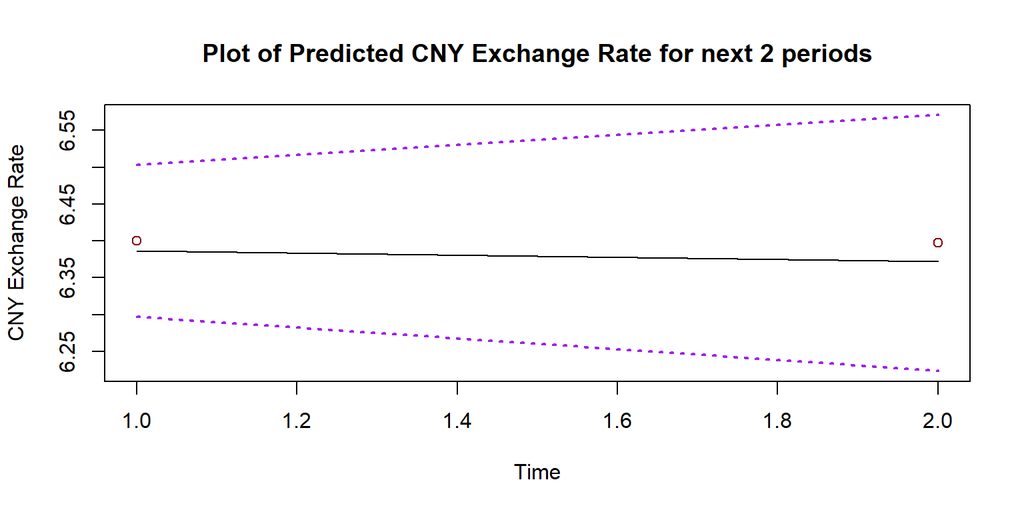

```r
#z=1.645

working.model = final_model_cn_m
TimeSeriesDataTest = monthly.CNY.ts.test
## Forecasting with ARIMA: 8 Weeks Ahead
n = length(TimeSeriesDataTest)
#nfit = n-14
#outvol = arima(volume.ts[1:nfit], order = c(5,1,5),seasonal = list(order = c(1,0,1),period=7),method = "ML")
out_pred = as.vector(predict(working.model,n.ahead=2))

## Compare predictions vs observed values with confidence bands
timevol=time(TimeSeriesDataTest)
ubound = out_pred$pred+1.645*out_pred$se
lbound = out_pred$pred-1.645*out_pred$se
ymin = min(lbound)
ymax = max(ubound)
par(mfrow=c(1,1))
plot(timevol,TimeSeriesDataTest,type="l", ylim=c(ymin,ymax), xlab="Time", ylab="CNY Exchange Rate", main = "Plot of Predicted CNY Exchange Rate for next 2 periods")
points(timevol[(1):n],out_pred$pred,col="darkred")
lines(timevol[(1):n],ubound,lty=3,lwd= 2, col="purple")
lines(timevol[(1):n],lbound,lty=3,lwd= 2, col="purple")
```

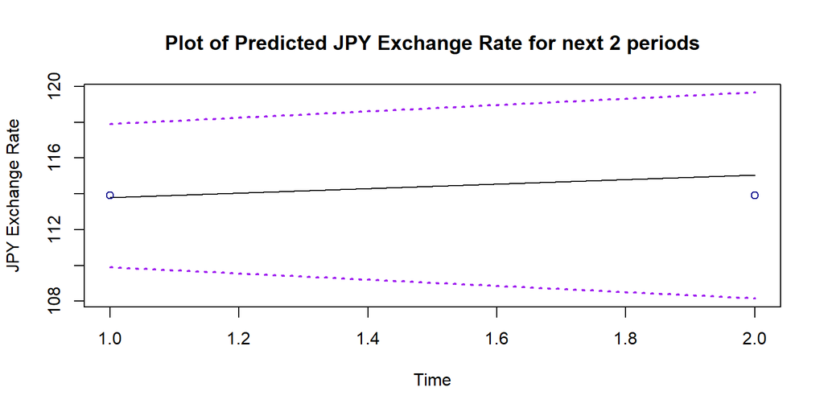

```r
out_pred_cny_m = out_pred


#Now for JPY
working.model = final_model_jpy_m
TimeSeriesDataTest = monthly.JPY.ts.test
## Forecasting with ARIMA: 8 Weeks Ahead
n = length(TimeSeriesDataTest)
out_pred = as.vector(predict(working.model,n.ahead=2))


## Compare predictions vs observed values with confidence bands
timevol=time(TimeSeriesDataTest)
ubound = out_pred$pred+1.645*out_pred$se
lbound = out_pred$pred-1.645*out_pred$se
ymin = min(lbound)
ymax = max(ubound)
par(mfrow=c(1,1))
plot(timevol,TimeSeriesDataTest,type="l", ylim=c(ymin,ymax), xlab="Time", ylab="JPY Exchange Rate", main = "Plot of Predicted JPY Exchange Rate for next 2 periods")
points(timevol[(1):n],out_pred$pred,col="darkblue")
lines(timevol[(1):n],ubound,lty=3,lwd= 2, col="purple")
lines(timevol[(1):n],lbound,lty=3,lwd= 2, col="purple")
```

```r
out_pred_jpy_m = out_pred
```

**3c.** Calculate Mean Absolute Percentage Error (MAPE) and Precision Measure (PM). How many observations are within the prediction bands? Compare the accuracy of the predictions for the two time series using these two measures.

```r
out_pred = out_pred_cny_m
TimeSeriesDataTest = monthly.CNY.ts.test
#MAPE
mean(abs((TimeSeriesDataTest-out_pred$pred)/TimeSeriesDataTest)) * 100 #in percent
```

```
## [1] 0.2985237
```

```r
### Precision Measure (PM)
sum((TimeSeriesDataTest - out_pred$pred)^2)/sum((TimeSeriesDataTest-mean(TimeSeriesDataTest))^2)
```

```
## [1] 7.182375
```

```r
out_pred = out_pred_jpy_m
TimeSeriesDataTest = monthly.JPY.ts.test
#MAPE
mean(abs((TimeSeriesDataTest-out_pred$pred)/TimeSeriesDataTest)) * 100 #in percent
```

```
## [1] 0.5475758
```

```r
### Precision Measure (PM)
sum((TimeSeriesDataTest - out_pred$pred)^2)/sum((TimeSeriesDataTest-mean(TimeSeriesDataTest))^2)
```

```
## [1] 1.706288
```

*Response: Predictions*

For monthly CNY, the MAPE is 0.2985237 and the PM is 7.182375. We see from the plots above that both monthly data points, along with all the data, is within the 90% prediction bands.

For monthly JPY, the MAPE is 0.5475758 and the PM is 1.706288. We see from the plots above that both monthly data points, along with all the data, is within the 90% prediction bands.

In comparing the MAPE and PM for both currencies for the monthly data, we see that the MAPE is higher for JPY with respect to CNY, however the PM is lower. MAPE estimates by minimizing absolute prediction errors, and since the CNY monthly is lower than the JPY value, it suggests that the CNY is a better fit. However, the closer the PM values is to zero, the better the prediction is. With a lower PM, the JPY monthly model is a better fit than that of CNY.

# Question 4. Weekly vs Monthly Forecasting (5 points)

Compare the forecasts based on the weekly versus monthly data. Overlay the forecast into one single plot for each of the two currency exchange rates. What can you say about using weekly versus monthly data?

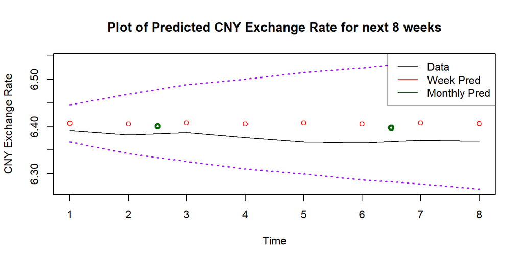

```r
#plot both predictions for cny
TimeSeriesDataTest = weekly.CNY.ts.test
timevol=time(weekly.CNY.ts.test, frequency = 52)

ubound = out_pred_cny$pred+1.645*out_pred_cny$se
lbound = out_pred_cny$pred-1.645*out_pred_cny$se
ymin = min(lbound)
ymax = max(ubound)

n=length(TimeSeriesDataTest)
plot(timevol,TimeSeriesDataTest,type="l", ylim=c(ymin,ymax), xlab="Time", ylab="CNY Exchange Rate", main = "Plot of Predicted CNY Exchange Rate for next 8 weeks")
points(timevol[(1):n],out_pred_cny$pred,col="red")
points(timevol[(1):(n/4)]*4-1.5,out_pred_cny_m$pred,col="darkgreen",lwd= 3)
lines(timevol[(1):n],ubound,lty=3,lwd= 2, col="purple")
lines(timevol[(1):n],lbound,lty=3,lwd= 2, col="purple")
legend("topright",
       c("Data", "Week Pred", "Monthly Pred"),
       lty = 1,
       col = c("black","red","darkgreen"))
```

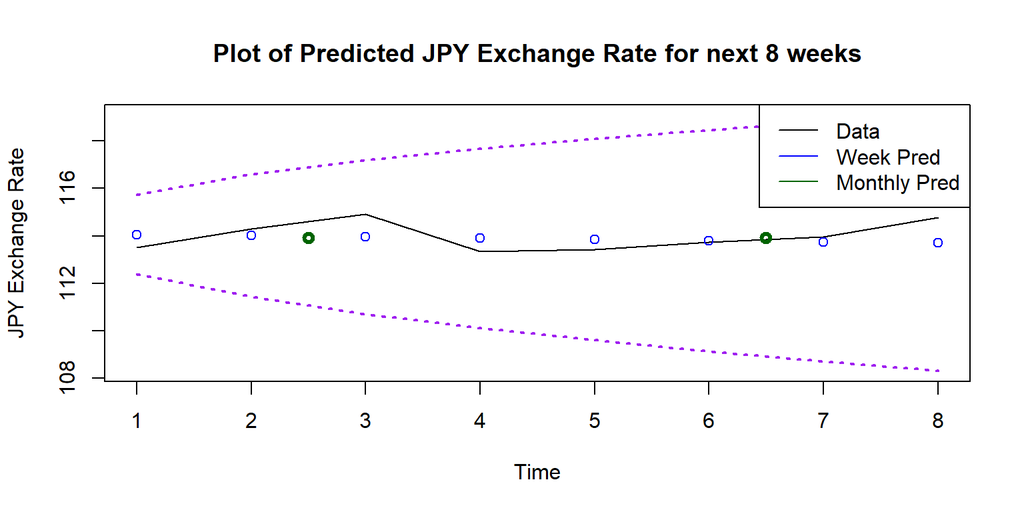

```r
#plot both predictions for jpy
TimeSeriesDataTest = weekly.JPY.ts.test
timevol=time(weekly.JPY.ts.test, frequency = 52)

ubound = out_pred_jpy$pred+1.645*out_pred_jpy$se
lbound = out_pred_jpy$pred-1.645*out_pred_jpy$se
ymin = min(lbound)
ymax = max(ubound)
n=length(TimeSeriesDataTest)
plot(timevol,TimeSeriesDataTest,type="l", ylim=c(ymin,ymax), xlab="Time", ylab="JPY Exchange Rate", main = "Plot of Predicted JPY Exchange Rate for next 8 weeks")
points(timevol[(1):n],out_pred_jpy$pred,col="blue")
points(timevol[(1):(n/4)]*4-1.5,out_pred_jpy_m$pred,col="darkgreen",lwd= 3)
lines(timevol[(1):n],ubound,lty=3,lwd= 2, col="purple")
lines(timevol[(1):n],lbound,lty=3,lwd= 2, col="purple")
legend("topright",
       c("Data", "Week Pred", "Monthly Pred"),
       lty = 1,
       col = c("black","blue","darkgreen"))
```

*Response: Prediction Comparison*

In the CNY dataset, we see that the monthly predictions, which are in green, are slightly closer to the actual weekly data points when compared to the weekly predictions. Please note that i centered the data points in the middle of the month to more easily describe. This makes sense, since the monthly data set, which is the average of the values for that month, inherently is smoother, and perhaps more stationary than that of the weekly dataset, as it is an average. As such, the slightly fluctuation in currency prices would not be represented in the dataset, are it is inherently less volatile.

In the JPY dataset, we see the we see the same, but given a wider range in the weekly values, much of the nuanced volatility is not captured. From a percentage variation, this is likely minimal, but when plotted as absolute points, it appears the weekly prediction best captures this nuance.

# Question 5. Reflection on ARIMA (5 points)

Considering your understanding of the ARIMA model in general as well as what your understanding of the behavior of the currency exchange data based on the completion of the above questions, how would you personally regard the effectiveness of ARIMA modelling? Where would it be appropriate to use it for forecasting and where would you recommend against? What are some specific points of caution one would need to consider when considering using it?

*Response: Reflection on ARIMA*

I personally was surprised as how well ARIMA modeling fit the currency exchange data. I do think that it would be appropriate for forecasting, but only in the short term, looking at most a few weeks out. We saw that the 90% prediction bands were diverging as time went out, expecting increased volatility. I would caution on using data without considering the training period to ensure that there were no external factors, such as currency pegging or change in leadership that would naturally cause the exchange rate to become more volatile than normal. The same reasoning is that you should not look to predict into a time period where those factors exist. I do recommend extensive goodness of fit and residual analysis, as we saw that the quality of the fit can easily change depending on the order of the model and the frequency of the measurement within the training data.